# TP1 Analyse en Composantes Principales

Ibtihel rebhi (Groupes A, C, D) Ghazi Bel Mufti (Groupe B)

16 septembre 2018

I. Exploration et visualisation des données

La base de données Decathlon se trouve dans le package FactoMineR. Les données contiennent les performances d’athlètes lors de deux compétitions (Jeux Olympiques de 2004 ou Décastar 2004). Le tableau de données contient 41 lignes et 13 colonnes. Les colonnes de 1 à 12 sont des variables quantitatives : les dix premières colonnes correspondent aux performances des athlètes pour les dix épreuves du décathlon et les colonnes 11 et 12 correspondent respectivement au rang et au nombre de points obtenus. La dernière colonne est une variable qualitative correspondant au nom de la compétition.

Q1. Importer et explorer le jeu de données

```r
library(FactoMineR)
data(decathlon)
head(decathlon)
tail(decathlon)
str(decathlon)
# competition est une variable nominale, catégorielle comme sexe (H ou F). Le reste des variables sont soit quantitatives discrètes (Points, Rank) soit continues (100m, Discus).
```

[output not shown]

```r
summary(decathlon)
```

```
##       100m         Long.jump       Shot.put       High.jump
##  Min.   :10.44   Min.   :6.61   Min.   :12.68   Min.   :1.850
##  1st Qu.:10.85   1st Qu.:7.03   1st Qu.:13.88   1st Qu.:1.920
##  Median :10.98   Median :7.30   Median :14.57   Median :1.950
##  Mean   :11.00   Mean   :7.26   Mean   :14.48   Mean   :1.977
##  3rd Qu.:11.14   3rd Qu.:7.48   3rd Qu.:14.97   3rd Qu.:2.040
##  Max.   :11.64   Max.   :7.96   Max.   :16.36   Max.   :2.150
##       400m        110m.hurdle        Discus        Pole.vault
##  Min.   :46.81   Min.   :13.97   Min.   :37.92   Min.   :4.200
##  1st Qu.:48.93   1st Qu.:14.21   1st Qu.:41.90   1st Qu.:4.500
##  Median :49.40   Median :14.48   Median :44.41   Median :4.800
##  Mean   :49.62   Mean   :14.61   Mean   :44.33   Mean   :4.762
##  3rd Qu.:50.30   3rd Qu.:14.98   3rd Qu.:46.07   3rd Qu.:4.920
##  Max.   :53.20   Max.   :15.67   Max.   :51.65   Max.   :5.400
##     Javeline         1500m            Rank           Points
##  Min.   :50.31   Min.   :262.1   Min.   : 1.00   Min.   :7313
##  1st Qu.:55.27   1st Qu.:271.0   1st Qu.: 6.00   1st Qu.:7802
##  Median :58.36   Median :278.1   Median :11.00   Median :8021
##  Mean   :58.32   Mean   :279.0   Mean   :12.12   Mean   :8005
##  3rd Qu.:60.89   3rd Qu.:285.1   3rd Qu.:18.00   3rd Qu.:8122
##  Max.   :70.52   Max.   :317.0   Max.   :28.00   Max.   :8893
##    Competition
##  Decastar:13
##  OlympicG:28
##
##
##
##
```

```r
attach(decathlon)
table(Points) # 2 athlètes ont le même score soit 7708, 8067
```

```
## Points
## 7313 7404 7495 7573 7583 7592 7651 7708 7733 7802 7865 7893 7918 7926 7934
##    1    1    1    1    1    1    1    2    1    1    1    1    1    1    1
## 7993 7995 8004 8006 8021 8023 8030 8036 8067 8077 8084 8099 8102 8122 8217
##    1    1    1    1    1    1    1    1    2    1    1    1    1    1    1
## 8225 8235 8237 8287 8343 8414 8725 8820 8893
##    1    1    1    1    1    1    1    1    1
```

```r
#Le mode s'obtient par lecture de la table des effectifs en prenant la modalité correpondant au plus grand effectif.
sort(table(Points),decreasing=TRUE)
```

```
## Points
## 7708 8067 7313 7404 7495 7573 7583 7592 7651 7733 7802 7865 7893 7918 7926
##    2    2    1    1    1    1    1    1    1    1    1    1    1    1    1
## 7934 7993 7995 8004 8006 8021 8023 8030 8036 8077 8084 8099 8102 8122 8217
##    1    1    1    1    1    1    1    1    1    1    1    1    1    1    1
## 8225 8235 8237 8287 8343 8414 8725 8820 8893
##    1    1    1    1    1    1    1    1    1
```

```r
names(which.max(table(Points)))
```

```
## [1] "7708"
```

```r
median(Points)
```

```
## [1] 8021
```

```r
var(Points)
```

```
## [1] 117227.6
```

```r
sd(Points)
```

```
## [1] 342.3851
```

Q2. Représenter des tableaux résumés des scores des athlètes selon la compétition (ddply dans package plyr avec le paramètre summarise)

```r
library(plyr)
ddply(decathlon, .(Competition),summarise,
      N = sum(Javeline),
mean = mean(Javeline),
sd = sd(Javeline))
```

```
##   Competition       N     mean       sd
## 1    Decastar  740.41 56.95462 4.360066
## 2    OlympicG 1650.57 58.94893 4.975849
```

```r
ddply(decathlon, c("Competition"), summarise,
N = sum(Javeline),
mean = mean(Javeline),
sd = sd(Javeline))
```

```
##   Competition       N     mean       sd
## 1    Decastar  740.41 56.95462 4.360066
## 2    OlympicG 1650.57 58.94893 4.975849
```

Q3. Centrer et réduire les variables (quantitatives) d’interêt.

```r
X=data.frame(scale(decathlon[,-c(11,13)]),decathlon$Competition)
colnames(X)=colnames(decathlon)[-11]
```

Q4. Comparer les résultats des deux compétitions pour toutes les variables quantitatives. Penser à représenter les boxplots de toutes les variables quantitatives (melt dans reshape2 pour préparer le jeu de données et facet_wrap dans ggplot2 pour visualiser)

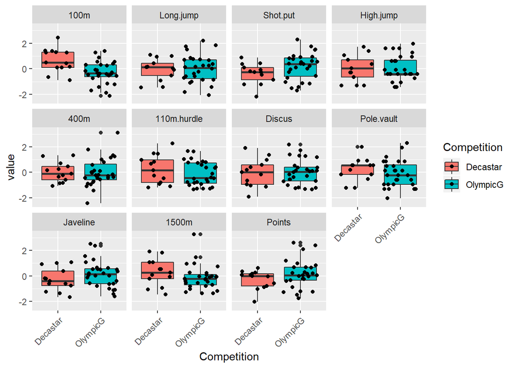

```r
library(reshape2)
dfmelt<-melt(X, measure.vars = 1:11)
library(ggplot2)
gr<-ggplot(dfmelt, aes(y=value, x=Competition,  fill=Competition))+
geom_boxplot() + theme(axis.text.x = element_text(angle = 45, hjust = 1))+
geom_jitter() +facet_wrap(~variable)

gr
```

Q5. Etudier les corréations entre les variables quantitatives. Penser à tracer un corrgram.

[figure not shown]

```r
library(corrgram)
corrgram(X[,-12], order=TRUE,lower.panel=panel.conf)
```

2. Programmer les étapes de L’ACP normée

On définit la matrice $X$ composé des dix scores des dix épreuves du decathlon. On définit la matrice $D=\displaystyle\frac{1}{n}I_n$, $n$ étant la taille de l’échantillon. Puisque les variables ont des unités de mesures différentes, on procède au centrage (retrancher de chaque variable la moyenne) et à la réduction des variables de $X$ (diviser chaque variable par son écart-type)

```r
X=as.matrix(decathlon[,1:10])
g=colMeans(X)
g
```

```
##        100m   Long.jump    Shot.put   High.jump        400m 110m.hurdle
##   10.998049    7.260000   14.477073    1.976829   49.616341   14.605854
##      Discus  Pole.vault    Javeline       1500m
##   44.325610    4.762439   58.316585  279.024878
```

Centrage de la matrice X

```r
X=sweep(x=X,2,g,FUN = '-')
round(colMeans(X),3)
```

```
##        100m   Long.jump    Shot.put   High.jump        400m 110m.hurdle
##           0           0           0           0           0           0
##      Discus  Pole.vault    Javeline       1500m
##           0           0           0           0
```

Calcul des écarts-types et réduction des variables de $X$. Ainsi la matrice $M=I_p$.

```r
n=nrow(X)
p=ncol(X)
et=apply(X,2,function(x) sqrt(sum(x^2)/n))
et
```

```
##        100m   Long.jump    Shot.put   High.jump        400m 110m.hurdle
##  0.25979560  0.31251927  0.81431175  0.08785906  1.13929751  0.46599998
##      Discus  Pole.vault    Javeline       1500m
##  3.33639725  0.27458865  4.76759315 11.53001177
```

```r
X=sweep(x=X,2,et,FUN = '/')
colSums(X^2)/n
```

```
##        100m   Long.jump    Shot.put   High.jump        400m 110m.hurdle
##           1           1           1           1           1           1
##      Discus  Pole.vault    Javeline       1500m
##           1           1           1           1
```

```r
M=diag(rep(1,p))
D=(1/n)*diag(rep(1,n))
```

Calcul des valeurs et vecteurs propres de la matrice de variance $V=X'DX$ étant donné que $M=I_p$.

```r
V=t(X)%*%D%*%X
vp=eigen(M%*%V)
lambda=vp$values
lambda
```

```
##  [1] 3.2719055 1.7371310 1.4049167 1.0568504 0.6847735 0.5992687 0.4512353
##  [8] 0.3968766 0.2148149 0.1822275
```

```r
v=vp$vectors
```

Vérifions que les vecteurs colonnes de la matrice sont bien des vecteurs orthornormés.

```r
round(t(v)%*%v,3)
```

```
##       [,1] [,2] [,3] [,4] [,5] [,6] [,7] [,8] [,9] [,10]
##  [1,]    1    0    0    0    0    0    0    0    0     0
##  [2,]    0    1    0    0    0    0    0    0    0     0
##  [3,]    0    0    1    0    0    0    0    0    0     0
##  [4,]    0    0    0    1    0    0    0    0    0     0
##  [5,]    0    0    0    0    1    0    0    0    0     0
##  [6,]    0    0    0    0    0    1    0    0    0     0
##  [7,]    0    0    0    0    0    0    1    0    0     0
##  [8,]    0    0    0    0    0    0    0    1    0     0
##  [9,]    0    0    0    0    0    0    0    0    1     0
## [10,]    0    0    0    0    0    0    0    0    0     1
```

Calculons la matrice $C$ des composantes principales qui est donnée par $C=Xu$. On verifiera que la variance de chaque composante est égale à la valeur propore correspondante.

```r
C=X%*%v
round(t(C)%*%D%*%C,3)
```

```
##        [,1]  [,2]  [,3]  [,4]  [,5]  [,6]  [,7]  [,8]  [,9] [,10]
##  [1,] 3.272 0.000 0.000 0.000 0.000 0.000 0.000 0.000 0.000 0.000
##  [2,] 0.000 1.737 0.000 0.000 0.000 0.000 0.000 0.000 0.000 0.000
##  [3,] 0.000 0.000 1.405 0.000 0.000 0.000 0.000 0.000 0.000 0.000
##  [4,] 0.000 0.000 0.000 1.057 0.000 0.000 0.000 0.000 0.000 0.000
##  [5,] 0.000 0.000 0.000 0.000 0.685 0.000 0.000 0.000 0.000 0.000
##  [6,] 0.000 0.000 0.000 0.000 0.000 0.599 0.000 0.000 0.000 0.000
##  [7,] 0.000 0.000 0.000 0.000 0.000 0.000 0.451 0.000 0.000 0.000
##  [8,] 0.000 0.000 0.000 0.000 0.000 0.000 0.000 0.397 0.000 0.000
##  [9,] 0.000 0.000 0.000 0.000 0.000 0.000 0.000 0.000 0.215 0.000
## [10,] 0.000 0.000 0.000 0.000 0.000 0.000 0.000 0.000 0.000 0.182
```

Calculons les coordonnées des variables sur les axes principaux. D’abord calculons la matrice des axes principaux

```r
Lambda=diag(lambda)
Z=C%*%solve(sqrt(Lambda))
CoordX=t(X)%*%D%*%Z
```

Autre manière (cf. cours)

```r
Z<-sweep(v,2,sqrt(lambda),FUN='*')
```

3. Mise en oeuvre de l’ACP avec les packages FactoMineR, Factoextra, princomp et pca3d.

Utilisons maintenant la fonction PCA pour vérifier les résultats obtenus

```r
library(FactoMineR)
colnames(decathlon)
```

```
##  [1] "100m"        "Long.jump"   "Shot.put"    "High.jump"   "400m"
##  [6] "110m.hurdle" "Discus"      "Pole.vault"  "Javeline"    "1500m"
## [11] "Rank"        "Points"      "Competition"
```

```r
res.pca=PCA(decathlon,ncp = 5,quanti.sup = 11:12,quali.sup = 13,graph = F)
names(res.pca)
```

```
## [1] "eig"        "var"        "ind"        "svd"        "quanti.sup"
## [6] "quali.sup"  "call"
```

L’objet $\texttt{eig}$ est une matrice à trois colonnes contenants respectivement les valeurs propres de l’ACP, la proportion de variance de chaque composante et les variance cumulées par les composantes principales.

```r
head(res.pca$eig)
```

```
##        eigenvalue percentage of variance cumulative percentage of variance
## comp 1  3.2719055              32.719055                          32.71906
## comp 2  1.7371310              17.371310                          50.09037
## comp 3  1.4049167              14.049167                          64.13953
## comp 4  1.0568504              10.568504                          74.70804
## comp 5  0.6847735               6.847735                          81.55577
## comp 6  0.5992687               5.992687                          87.54846
```

L’objet $\texttt{var}$ contient à son tour plusieurs autres objets

```r
names(res.pca$var)
```

```
## [1] "coord"   "cor"     "cos2"    "contrib"
```

L’objet $\texttt{coord}$ dans $\texttt{var}$ contient les coordonnées des variables sur les axes factoriels. Cet objet est exactement égal à la matrice dont les colonnes $\eta^1,\ldots,\eta^p$ où chaque $\eta^k$ est égal à $\sqrt{\lambda_k}u^k$. Donc l’objet $\texttt{coord}$ est la matrice
$$\mathbf{u} \sqrt{\Lambda}$$

```r
res.pca$var$coord
```

```
##                   Dim.1      Dim.2       Dim.3       Dim.4       Dim.5
## 100m        -0.77471983  0.1871420 -0.18440714 -0.03781826  0.30219639
## Long.jump    0.74189974 -0.3454213  0.18221105  0.10178564  0.03667805
## Shot.put     0.62250255  0.5983033 -0.02337844  0.19059161  0.11115082
## High.jump    0.57194530  0.3502936 -0.25951193 -0.13559420  0.55543957
## 400m        -0.67960994  0.5694378  0.13146970  0.02930198 -0.08769157
## 110m.hurdle -0.74624532  0.2287933 -0.09263738  0.29083103  0.16432095
## Discus       0.55246652  0.6063134  0.04295225 -0.25967143 -0.10482712
## Pole.vault   0.05034151 -0.1803569  0.69175665  0.55153397  0.32995932
## Javeline     0.27711085  0.3169891 -0.38965541  0.71227728 -0.30512892
## 1500m       -0.05807706  0.4742238  0.78214280 -0.16108904 -0.15356189
```

L’objet $\texttt{cos2}$ dans $\texttt{var}$ est une matrice dans chaque ligne représente sur une variable et chaque colonne est composée des carrés de la corrélation de la variable avec la composante principale correspondante

Une meilleure représentation …

```r
require(devtools)
require(factoextra)
```

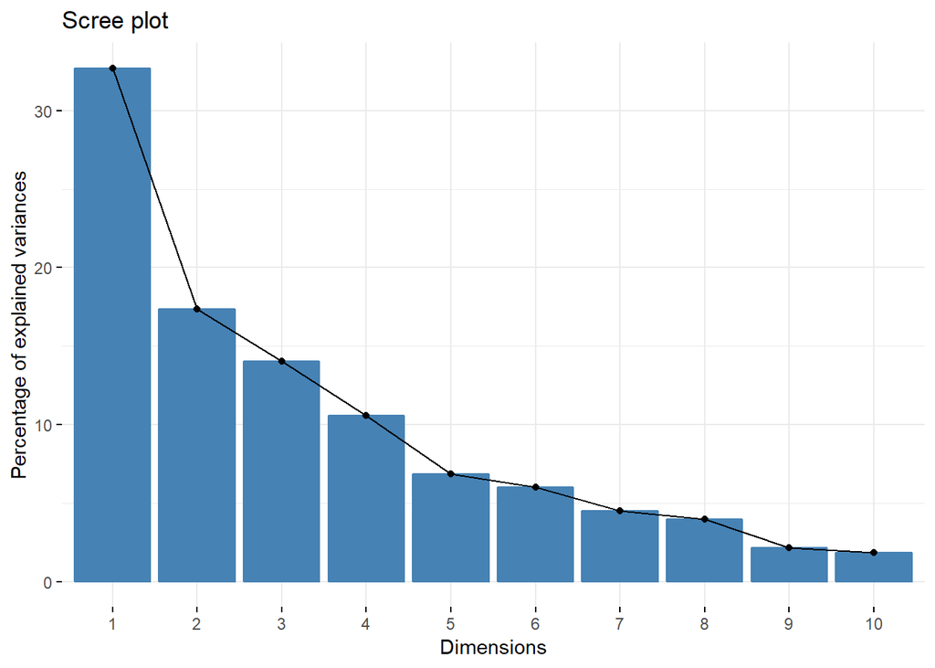

```r
fviz_screeplot(res.pca, ncp=10)
```

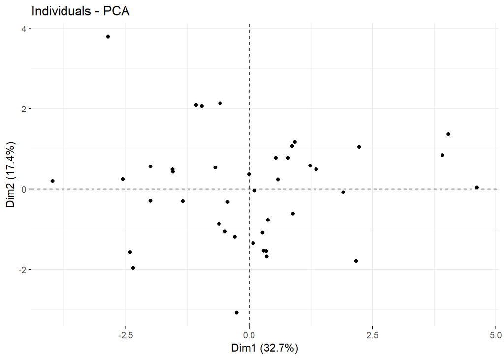

```r
fviz_pca_ind(res.pca,geom = "point",col.ind.sup = 'gray')
```

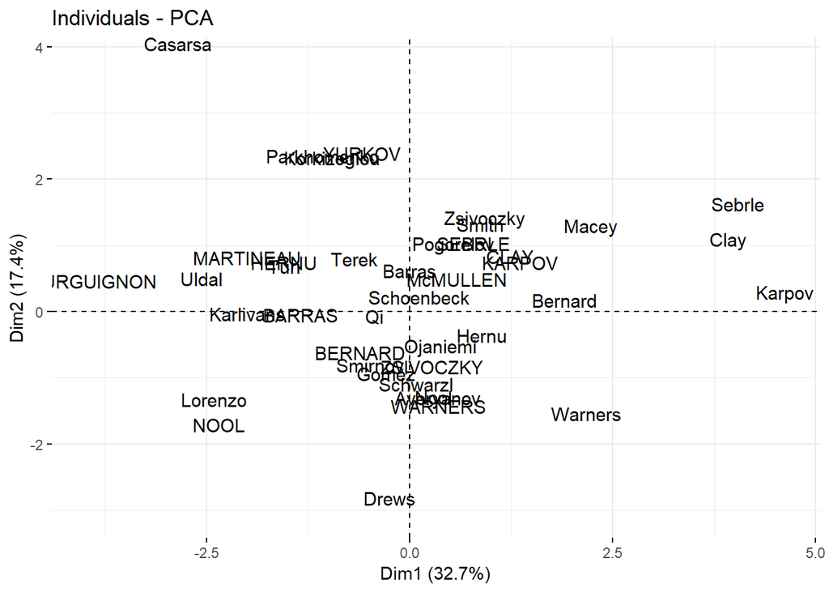

```r
fviz_pca_ind(res.pca,geom = "text",col.ind.sup = 'gray')
```

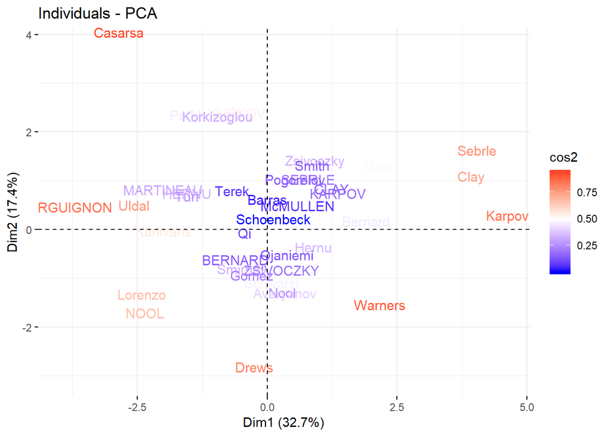

```r
fviz_pca_ind(res.pca,geom = "text",col.ind="cos2")+
scale_color_gradient2(low="blue", mid="white",
                      high="red", midpoint=0.5)
```

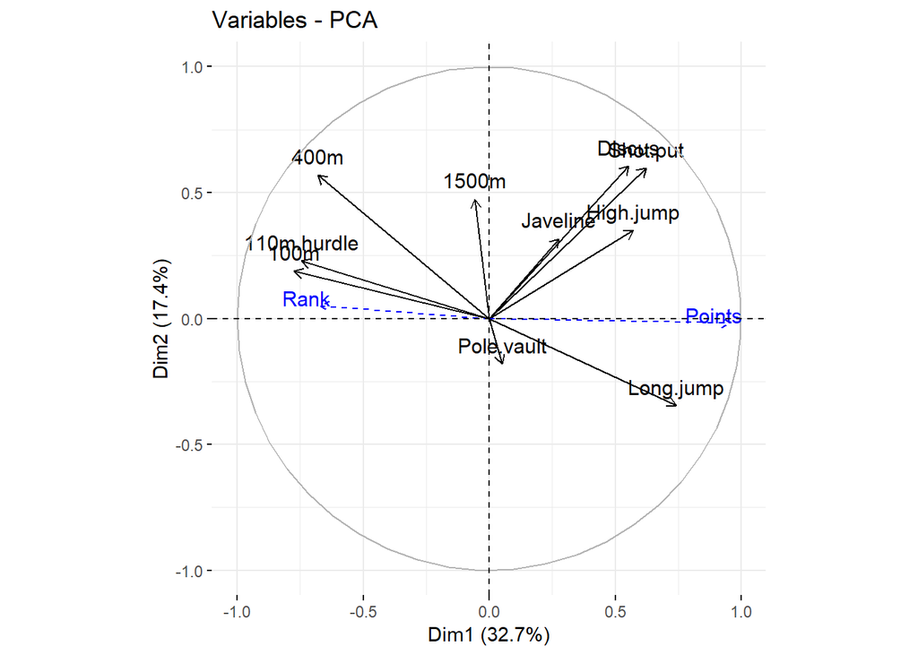

```r
fviz_pca_var(res.pca)
```

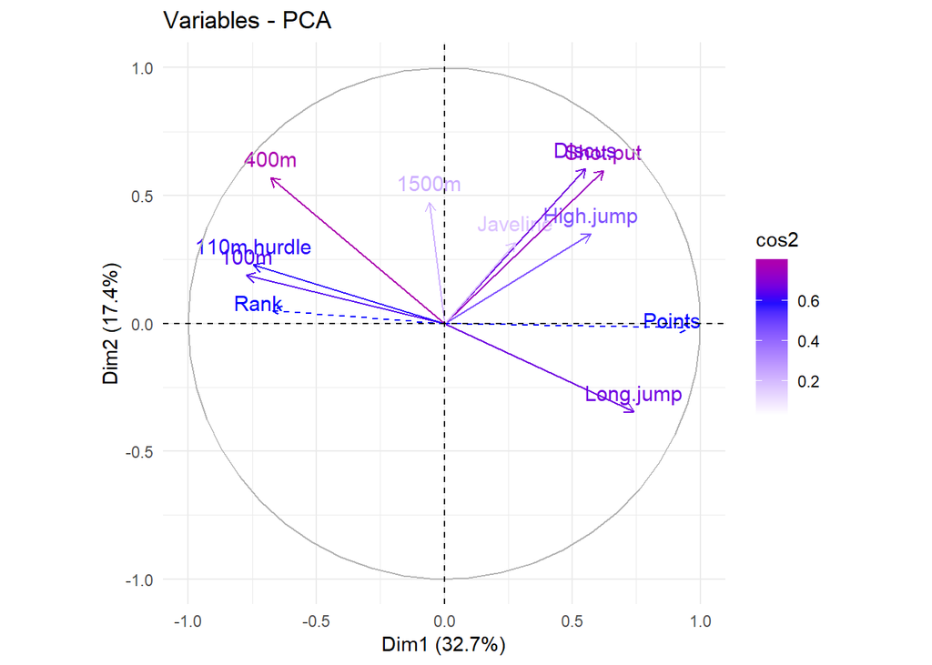

```r
fviz_pca_var(res.pca, col.var="cos2") +
  scale_color_gradient2(low="white", mid="blue",
                        high="red", midpoint=0.6) +
  theme_minimal()
```

## La fonction princomp()

```r
> res.pca3=princomp(x = decathlon[,1:10],scores = T,cor = T)
> summary(res.pca3)
Importance of components:
                          Comp.1    Comp.2    Comp.3    Comp.4     Comp.5
Standard deviation     1.8088409 1.3180027 1.1852918 1.0280323 0.82751044
Proportion of Variance 0.3271906 0.1737131 0.1404917 0.1056850 0.06847735
Cumulative Proportion  0.3271906 0.5009037 0.6413953 0.7470804 0.81555771
                           Comp.6     Comp.7     Comp.8     Comp.9
Standard deviation     0.77412446 0.67174047 0.62998142 0.46348123
Proportion of Variance 0.05992687 0.04512353 0.03968766 0.02148149
Cumulative Proportion  0.87548458 0.92060811 0.96029577 0.98177725
                          Comp.10
Standard deviation     0.42688111
Proportion of Variance 0.01822275
Cumulative Proportion  1.00000000
> names(res.pca3)
[1] "sdev"     "loadings" "center"   "scale"    "n.obs"    "scores"
[7] "call"
```

Package ade4

```r
library(ade4)
decathlon2=decathlon[,1:10]
res.pca2 <- dudi.pca(decathlon2, scannf = FALSE, nf = 5)
summary(res.pca2)
```

```
## Class: pca dudi
## Call: dudi.pca(df = decathlon2, scannf = FALSE, nf = 5)
##
## Total inertia: 10
##
## Eigenvalues:
##     Ax1     Ax2     Ax3     Ax4     Ax5
##  3.2719  1.7371  1.4049  1.0569  0.6848
##
## Projected inertia (%):
##     Ax1     Ax2     Ax3     Ax4     Ax5
##  32.719  17.371  14.049  10.569   6.848
##
## Cumulative projected inertia (%):
##     Ax1   Ax1:2   Ax1:3   Ax1:4   Ax1:5
##   32.72   50.09   64.14   74.71   81.56
##
## (Only 5 dimensions (out of 10) are shown)
```

PCA en 3D

```r
library(pca3d)
pca3d( res.pca3, group= decathlon$Competition,
    fancy= TRUE, bg= "white",
    axes.color= "black" )
```

```
## [1] 0.09239975 0.07595690 0.05173105
## Creating new device
```